# Corpus analysis: the document-term matrix

=========================================

*(C) 2015 Wouter van Atteveldt, license: [CC-BY-SA]*

The most important object in frequency-based text analysis is the *document term matrix*. This matrix contains the documents in the rows and terms (words) in the columns, and each cell is the frequency of that term in that document.

In R, these matrices are provided by the `tm` (text mining) package. Although this package provides many functions for loading and manipulating these matrices, using them directly is relatively complicated.

Fortunately, the `RTextTools` package provides an easy function to create a document-term matrix from a data frame. To create a term document matrix from a simple data frame with a ‘text’ column, use the `create_matrix` function (with removeStopwords=F to make sure all words are kept):

```r
library(RTextTools)
input = data.frame(text=c("Chickens are birds", "The bird eats"))
m = create_matrix(input$text, removeStopwords=F)
```

We can inspect the resulting matrix m using the regular R functions to get e.g. the type of object and the dimensionality:

```r
class(m)
```

```
## [1] "DocumentTermMatrix"    "simple_triplet_matrix"
```

```r
dim(m)
```

```
## [1] 2 6
```

```r
m
```

```
## <<DocumentTermMatrix (documents: 2, terms: 6)>>
## Non-/sparse entries: 6/6
## Sparsity           : 50%
## Maximal term length: 8
## Weighting          : term frequency (tf)
```

So, `m` is a `DocumentTermMatrix`, which is derived from a `simple_triplet_matrix` as provided by the `slam` package. Internally, document-term matrices are stored as a *sparse matrix*: if we do use real data, we can easily have hundreds of thousands of rows and columns, while the vast majority of cells will be zero (most words don’t occur in most documents). Storing this as a regular matrix would waste a lot of memory. In a sparse matrix, only the non-zero entries are stored, as ‘simple triplets’ of (document, term, frequency).

As seen in the output of `dim`, Our matrix has only 2 rows (documents) and 6 columns (unqiue words). Since this is a fairly small matrix, we can visualize it using `as.matrix`, which converts the ‘sparse’ matrix into a regular matrix:

```r
as.matrix(m)
```

```
##     Terms
## Docs are bird birds chickens eats the
##    1   1    0     1        1    0   0
##    2   0    1     0        0    1   1
```

## Stemming and stop word removal

So, we can see that each word is kept as is. We can reduce the size of the matrix by dropping stop words and stemming (changing a word like ‘chickens’ to its base form or stem ‘chicken’): (see the create_matrix documentation for the full range of options)

```r
m = create_matrix(input$text, removeStopwords=T, stemWords=T, language='english')
dim(m)
```

```
## [1] 2 3
```

```r
as.matrix(m)
```

```
##     Terms
## Docs bird chicken eat
##    1    1       1   0
##    2    1       0   1
```

In RTextTools, the language for stemming and stop words can be given as a parameter, and the default is English. Note that stemming works relatively well for English, but is less useful for more highly inflected languages such as Dutch or German. An easy way to see the effects of the preprocessing is by looking at the colSums of a matrix, which gives the total frequency of each term:

```r
colSums(as.matrix(m))
```

```
##    bird chicken     eat
##       2       1       1
```

For more richly inflected languages like Dutch, the result is less promising:

```r
text = c("De kip eet", "De kippen hebben gegeten")
m = create_matrix(text, removeStopwords=T, stemWords=T, language="dutch")
colSums(as.matrix(m))
```

```
##   eet geget   kip  kipp
##     1     1     1     1
```

As you can see, *de* and *hebben* are correctly recognized as stop words, but *gegeten* (eaten) and *kippen* (chickens) have a different stem than *eet* (eat) and *kip* (chicken). German gets similarly bad results.

## Loading and analysing a larger dataset from AmCAT

If we want to move beyond stemming, one option is to use AmCAT to parse articles. Before we can proceed, we need to save our AmCAT password (only needed once, please don’t save the password in your file!) and log onto amcat:

```r
library(amcatr)
amcat.save.password("http://preview.amcat.nl", "username",  "password")
conn = amcat.connect("https://amcat.nl")
```

Now, we can upload articles from R using the `amcat.upload.articles` function, which we now demonstrate with a single article but which can also be used to upload many articles at once:

```r
articles = data.frame(text = "John is a great fan of chickens, and so is Mary", date="2001-01-01", headline="test")

aset = amcat.upload.articles(conn, project = 1, articleset="Test Florence", medium="test",
                             text=articles$text, date=articles$date, headline=articles$headline)
```

```
## Created articleset 21997: Test Florence in project 1
## Uploading 1 articles to set 21997
```

And we can then lemmatize this article and download the results directly to R using `amcat.gettokens`:

```r
amcat.gettokens(conn, project=1, articleset = aset, module = "corenlp_lemmatize")
```

```
## GET https://amcat.nl/api/v4/projects/1/articlesets/21997/tokens/?page=1&module=corenlp_lemmatize&page_size=1&format=csv
## GET https://amcat.nl/api/v4/projects/1/articlesets/21997/tokens/?page=2&module=corenlp_lemmatize&page_size=1&format=csv
```

```
##        word sentence pos   lemma offset       aid id pos1
## 1      John        1 NNP    John      0 114440106  1    M
## 2        is        1 VBZ      be      5 114440106  2    V
## 3         a        1  DT       a      8 114440106  3    D
## 4     great        1  JJ   great     10 114440106  4    A
## 5       fan        1  NN     fan     16 114440106  5    N
## 6        of        1  IN      of     20 114440106  6    P
## 7  chickens        1 NNS chicken     23 114440106  7    N
## 8         ,        1   ,       ,     31 114440106  8    .
## 9       and        1  CC     and     33 114440106  9    C
## 10       so        1  RB      so     37 114440106 10    B
## 11       is        1 VBZ      be     40 114440106 11    V
## 12     Mary        1 NNP    Mary     43 114440106 12    M
```

For a more serious application, we will use an existing article set: [set 16017](https://amcat.nl/navigator/projects/559/articlesets/16017/) in project 559, which contains the state of the Union speeches by Bush and Obama (each document is a single paragraph) The analysed tokens for this set can be downloaded with the following command:

```r
sotu.tokens = amcat.gettokens(conn, project=559, articleset = 16017, module = "corenlp_lemmatize", page_size = 100)
```

Note: the command above might take a while to complete. This data is also available directly from the semnet package:

```r
library(semnet)
data(sotu)
nrow(sotu.tokens)
```

```
## [1] 91473
```

```r
head(sotu.tokens, n=20)
```

```
##          word sentence  pos      lemma offset       aid id pos1 freq
## 1          It        1  PRP         it      0 111541965  1    O    1
## 2          is        1  VBZ         be      3 111541965  2    V    1
## 3         our        1 PRP$         we      6 111541965  3    O    1
## 4  unfinished        1   JJ unfinished     10 111541965  4    A    1
## 5        task        1   NN       task     21 111541965  5    N    1
## 6          to        1   TO         to     26 111541965  6    ?    1
## 7     restore        1   VB    restore     29 111541965  7    V    1
## 8         the        1   DT        the     37 111541965  8    D    1
## 9       basic        1   JJ      basic     41 111541965  9    A    1
## 10    bargain        1   NN    bargain     47 111541965 10    N    1
## 11       that        1  WDT       that     55 111541965 11    D    1
## 12      built        1  VBD      build     60 111541965 12    V    1
## 13       this        1   DT       this     66 111541965 13    D    1
## 14    country        1   NN    country     71 111541965 14    N    1
## 15          :        1    :          :     78 111541965 15    .    1
## 16        the        1   DT        the     80 111541965 16    D    1
## 17       idea        1   NN       idea     84 111541965 17    N    1
## 18       that        1   IN       that     89 111541965 18    P    1
## 19         if        1   IN         if     94 111541965 19    P    1
## 20        you        1  PRP        you     97 111541965 20    O    1
```

```r
library(corpustools)
dtm = dtm.create(documents=sotu.tokens$aid, terms=sotu.tokens$lemma, filter=sotu.tokens$pos1 %in% c("M","N"))
```

```
## Ignoring words with frequency lower than 5
## Ignoring words with less than 3 characters
## Ignoring words that contain numbers of non-word characters
```

```r
dtm
```

```
## <<DocumentTermMatrix (documents: 1089, terms: 907)>>
## Non-/sparse entries: 15896/971827
## Sparsity           : 98%
## Maximal term length: 14
## Weighting          : term frequency (tf)
```

## Corpus analysis: word frequency

```r
library(slam)
freq = col_sums(dtm)
# sort the list by reverse frequency using built-in order function:
freq = freq[order(-freq)]
head(freq, n=10)
```

```
##   America      year    people       job   country     world       tax
##       409       385       327       256       228       198       181
## Americans    nation  Congress
##       179       171       168
```

As can be seen, the most frequent terms are America and recurring issues like jobs and taxes. It can be useful to compute different metrics per term, such as term frequency, document frequency (how many documents does it occur), and td.idf (term frequency * inverse document frequency, which removes both rare and overly frequent terms). The function `term.statistics` from the `corpus-tools` package provides this functionality:

```r
terms = term.statistics(dtm)
terms = terms[order(-terms$termfreq), ]
head(terms, 10)
```

```
##                term characters number nonalpha termfreq docfreq reldocfreq
## America     America          7  FALSE    FALSE      409     346 0.31772268
## year           year          4  FALSE    FALSE      385     286 0.26262626
## people       people          6  FALSE    FALSE      327     277 0.25436180
## job             job          3  FALSE    FALSE      256     190 0.17447199
## country     country          7  FALSE    FALSE      228     202 0.18549128
## world         world          5  FALSE    FALSE      198     156 0.14325069
## tax             tax          3  FALSE    FALSE      181     102 0.09366391
## Americans Americans          9  FALSE    FALSE      179     158 0.14508724
## nation       nation          6  FALSE    FALSE      171     150 0.13774105
## Congress   Congress          8  FALSE    FALSE      168     149 0.13682277
##               tfidf
## America   0.1275801
## year      0.1540023
## people    0.1547707
## job       0.2102813
## country   0.1677862
## world     0.2127368
## tax       0.3308686
## Americans 0.2033421
## nation    0.1985566
## Congress  0.1917011
```

```r
subset = terms[!terms$number & !terms$nonalpha & terms$characters>2 & terms$termfreq>=25 & terms$reldocfreq<.25, ]
nrow(subset)
```

```
## [1] 192
```

```r
head(subset, n=10)
```

```
##                term characters number nonalpha termfreq docfreq reldocfreq
## job             job          3  FALSE    FALSE      256     190 0.17447199
## country     country          7  FALSE    FALSE      228     202 0.18549128
## world         world          5  FALSE    FALSE      198     156 0.14325069
## tax             tax          3  FALSE    FALSE      181     102 0.09366391
## Americans Americans          9  FALSE    FALSE      179     158 0.14508724
## nation       nation          6  FALSE    FALSE      171     150 0.13774105
## Congress   Congress          8  FALSE    FALSE      168     149 0.13682277
## time           time          4  FALSE    FALSE      166     137 0.12580349
## child         child          5  FALSE    FALSE      153     112 0.10284665
## economy     economy          7  FALSE    FALSE      150     122 0.11202938
##               tfidf
## job       0.2102813
## country   0.1677862
## world     0.2127368
## tax       0.3308686
## Americans 0.2033421
## nation    0.1985566
## Congress  0.1917011
## time      0.2070660
## child     0.2254874
## economy   0.2582953
```

```r
dtm_filtered = dtm.filter(dtm, terms=subset$term)
dim(dtm_filtered)
```

```
## [1] 1082  192
```

Which yields a much more managable dtm. As a bonus, we can use the `dtm.wordcloud` function in corpustools (which is a thin wrapper around the `wordcloud` package) to visualize the top words as a word cloud:

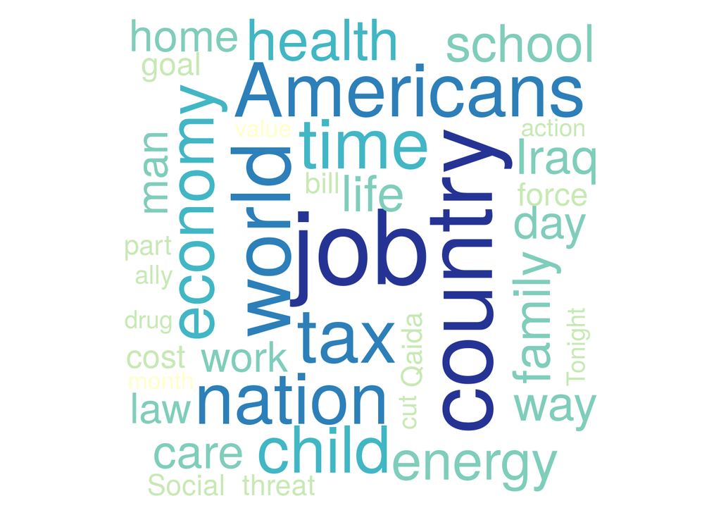

```r
dtm.wordcloud(dtm_filtered)
```

## Comparing corpora

Another useful thing we can do is comparing two corpora: Which words or names are mentioned more in e.g. Bush’ speeches than Obama’s.

To do this, we split the dtm in separate dtm’s for Bush and Obama. For this, we select docment ids using the `headline` column in the metadata from `sotu.meta`, and then use the `dtm.filter` function:

```r
head(sotu.meta)
```

```
##          id   medium     headline       date
## 1 111541965 Speeches Barack Obama 2013-02-12
## 2 111541995 Speeches Barack Obama 2013-02-12
## 3 111542001 Speeches Barack Obama 2013-02-12
## 4 111542006 Speeches Barack Obama 2013-02-12
## 5 111542013 Speeches Barack Obama 2013-02-12
## 6 111542018 Speeches Barack Obama 2013-02-12
```

```r
obama.docs = sotu.meta$id[sotu.meta$headline == "Barack Obama"]
dtm.obama = dtm.filter(dtm, documents=obama.docs)
bush.docs = sotu.meta$id[sotu.meta$headline == "George W. Bush"]
dtm.bush = dtm.filter(dtm, documents=bush.docs)
```

So how can we check which words are more frequent in Bush’ speeches than in Obama’s speeches? The function `corpora.compare` provides this functionality, given two document-term matrices:

```r
cmp = corpora.compare(dtm.obama, dtm.bush)
cmp = cmp[order(cmp$over), ]
head(cmp)
```

```
##          term termfreq.x termfreq.y    relfreq.x   relfreq.y      over
## 729    terror          1         55 0.0001121957 0.005824420 0.1629729
## 301   freedom          8         79 0.0008975654 0.008365985 0.2026018
## 242     enemy          4         52 0.0004487827 0.005506725 0.2226593
## 731 terrorist         10         73 0.0011219567 0.007730594 0.2430484
## 390      Iraq         15         94 0.0016829350 0.009954464 0.2449171
## 225      drug          4         39 0.0004487827 0.004130043 0.2824114
##          chi
## 729 49.81362
## 301 55.04010
## 242 39.11981
## 731 45.21642
## 390 54.06263
## 225 26.98837
```

Which words did Obama use most compared to Bush?

```r
cmp = cmp[order(cmp$over, decreasing=T), ]
head(cmp)
```

```
##         term termfreq.x termfreq.y   relfreq.x    relfreq.y     over
## 138  company         54          6 0.006058566 0.0006353913 4.316133
## 374 industry         32          1 0.003590261 0.0001058985 4.150708
## 132  college         55          9 0.006170762 0.0009530869 3.671502
## 124    class         26          1 0.002917087 0.0001058985 3.541995
## 396      job        200         56 0.022439134 0.0059303188 3.382115
## 190  deficit         56         11 0.006282957 0.0011648840 3.364133
##          chi
## 138 40.79339
## 374 30.63331
## 132 35.35282
## 124 24.35851
## 396 89.09458
## 190 32.46339
```

So, while Bush talks about freedom, war, and terror, Obama talks more about industry, banks and education.

Let’s make a word cloud of Obama’ words, with size indicating chi-square overrepresentation:

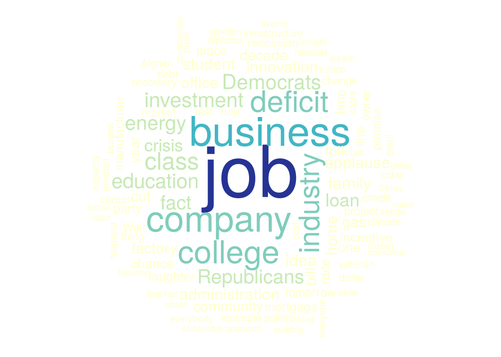

```r
obama = cmp[cmp$over > 1,]
dtm.wordcloud(terms = obama$term, freqs = obama$chi)
```

And Bush:

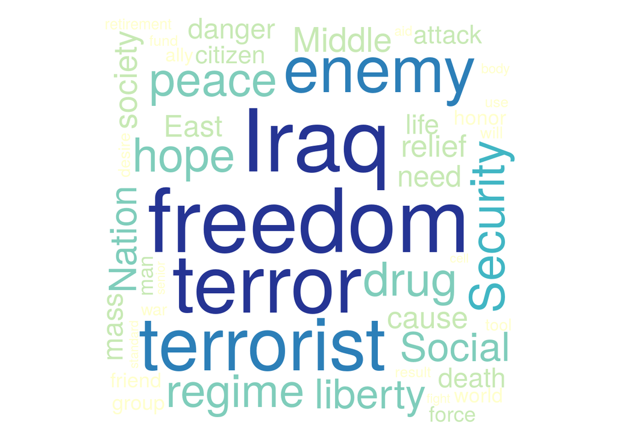

```r
bush = cmp[cmp$over < 1,]
dtm.wordcloud(terms = bush$term, freqs = bush$chi)
```

Note that the warnings given by these commands are relatively harmless: it means that some words are skipped because it couldn’t find a good place for them in the word cloud.